# second week: Introduction to R and Rstudio

Mobile Data

Mohammad amin Roohi

2018-02-20 01:46:58

# تمرین سری دوم: تلفن همراه شناسی!

> با استفاده از داده های گوشی های همراه به سوالات زیر پاسخ دهید. برای رسم نمودار از پکیج ggplot2 استفاده کنید.

۱. کدام شرکت بیشترین تعداد گوشی را تولید کرده است؟ نمودار ستونی ۲۰ شرکت برتر بر حسب تعداد گوشی تولید کرده را رسم کنید.

```r
#Q1

library(ggplot2)
library(devtools)
library(magrittr)
library(readr)
mobile = read.csv("D:/University/Semester8/Data analysis/week2/hw_02/mobile_data.csv")

t = table(mobile$company)

k = NULL

m = max(t)

d = dim(t)

for(i in 1 : d){

  if(t[i] == m){

    k = c(t[i])
  }
}
row.names(k)
print(row.names(k))
```

[output not shown]

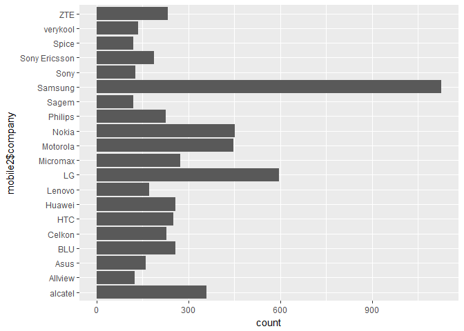

```r
com = sort(t , decreasing = TRUE)

y = NULL

com = com[1:20]



x = row.names(com)

f = rep(0 , length(mobile$company))

for(i in 1:length(x)){

  a = mobile$company == x[i]

  a = as.integer(a)

  f = f + a



}

for(i in 1:length(f)){

  if(f[i] == 1){

    y = c(y , i)
  }
}
mobile2 = mobile[y , ]

ggplot(mobile2 , aes(x = mobile2$company)) + geom_bar() + coord_flip()
```

۲. نمودار زمانی طول عرض ضخامت و کیفیت دوربین گوشی ها را بکشید و به نمودار هر یک مدل خطی اضافه کنید.

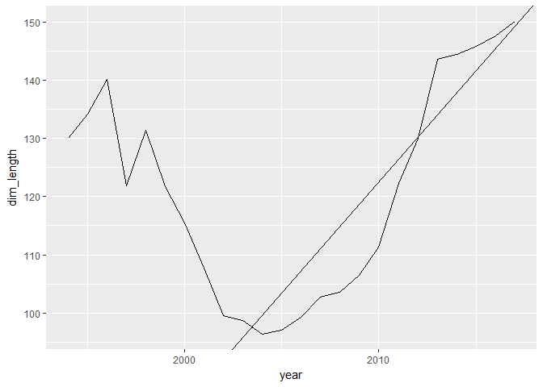

```r
#Q2


#dim_length


coef1 = coef(lm(mobile$dim_length ~ mobile$year, data = mobile))

ggplot(data = mobile , aes(year , dim_length))  + geom_line(stat = "summary" , fun.y = "mean") + geom_abline(intercept = coef1[1], slope = coef1[2])
```

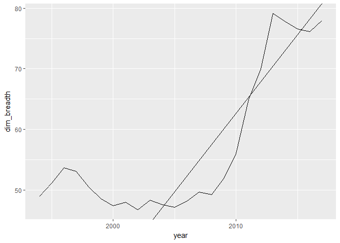

```r
#dim_breadth

coef2 = coef(lm(mobile$dim_breadth ~ mobile$year, data = mobile))

ggplot(data = mobile , aes(year , dim_breadth))  + geom_line(stat = "summary" , fun.y = "mean") + geom_abline(intercept = coef2[1], slope = coef2[2])
```

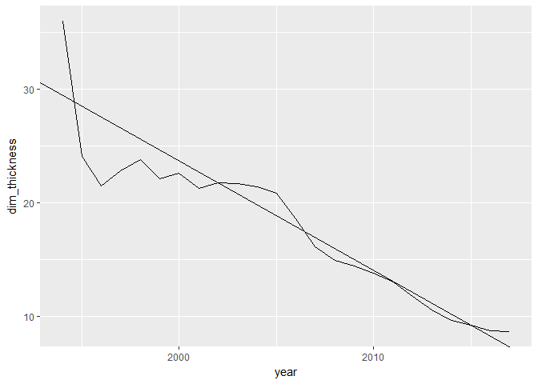

```r
#dim_thickness


coef3 = coef(lm(mobile$dim_thickness ~ mobile$year, data = mobile))

ggplot(data = mobile , aes(year , dim_thickness))  + geom_line(stat = "summary" , fun.y = "mean") + geom_abline(intercept = coef3[1], slope = coef3[2])
```

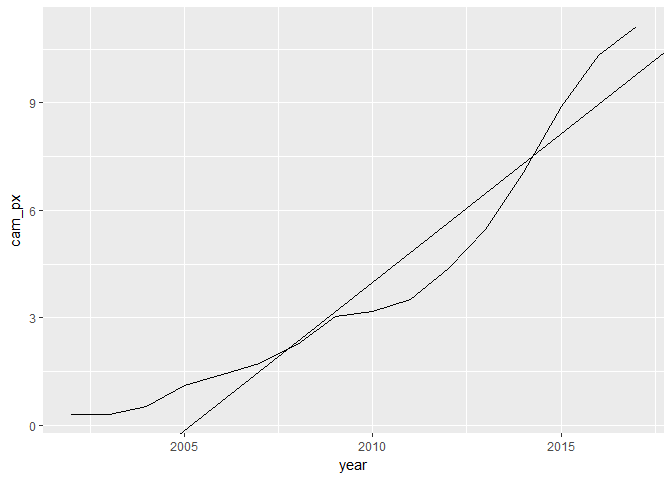

```r
#cam_px


coef4 = coef(lm(mobile$cam_px ~ mobile$year, data = mobile))

ggplot(data = mobile , aes(year , cam_px))  + geom_line(stat = "summary" , fun.y = "mean") + geom_abline(intercept = coef4[1], slope = coef4[2])
```

۳. نمودار ستونی متوسط قیمت گوشی بر حسب تعداد سیم کارت و دسترسی به LTE را رسم نمایید.

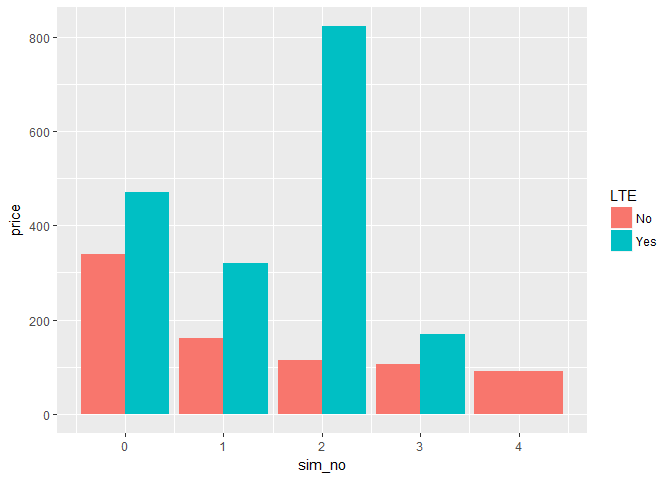

```r
ggplot(mobile , aes(fill = LTE , x = sim_no , y = price)) + geom_bar(stat = "summary" , fun.y = "mean" , position = "dodge")
```

۴. نمودار جعبه ایی ضحامت گوشی هایی که در سال ۲۰۱۷ معرفی شده اند را برحسب اینکه کمیت جک هدفون رسم نمایید

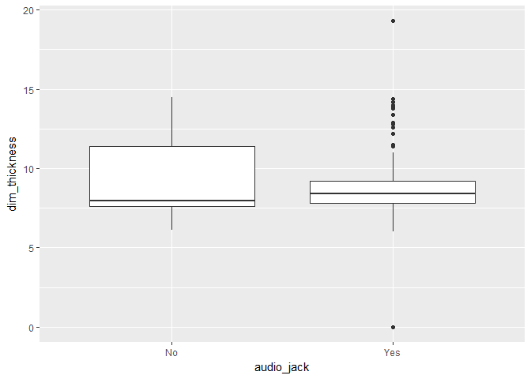

```r
mobile1 <- subset(mobile , year == 2017)



ggplot(data=na.omit(mobile1[,c("audio_jack","dim_thickness")]) , aes(audio_jack , dim_thickness)) + geom_boxplot(na.rm = T)
```

۵. مفهوم ppi را در گوشی های موبایل محاسبه و هیستوگرام آن را رسم نمایید. همچنین نمودار سالانه متوسط این کمیت را بکشید. کدام گوشی بیشترین ppi را دارد؟

```r
d = dim(mobile)

d = d[1]

ppi = NULL

for(i in 1:d){



  ppi = c(ppi , (mobile[i , 12] * mobile[i , 13]) / mobile[i , 11])



}

m = match(max(ppi , na.rm = T) , ppi)

print(paste(mobile[m , 1] , mobile[m , 2]))
```

```
## [1] "Sony Xperia XZ Premium"
```

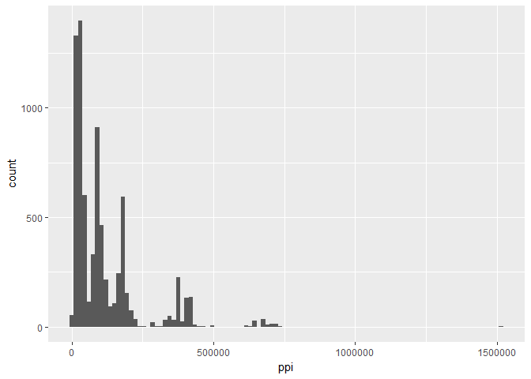

```r
ggplot(mobile , aes(ppi)) + geom_histogram(binwidth = 15000)
```

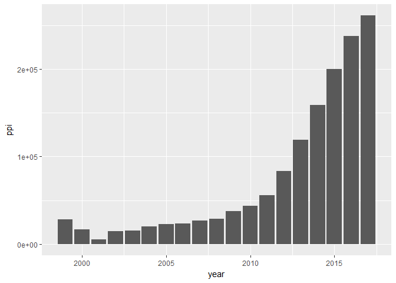

```r
ggplot(mobile , aes(year , ppi)) + geom_bar(stat = "summary" , fun.y = "mean")
```

۶. در گذشته به بعضی از مدل های گوشی نوکیا **گوشکوب** گفته می شد. سعی کنید برای این مفهوم کمیتی مناسب تعریف کنید . ده گوشکوب برتر را پیدا کرده و نمودار گوشکوبیت آن را رسم نمایید.

```r
d = dim(mobile)

d = d[1]

gooshkoobiat = NULL

for(i in 1:d){



  gooshkoobiat = c(gooshkoobiat , (((mobile[i , 8] * mobile[i , 9]) / (mobile[i , 7] *mobile[i , 4] * mobile[i , 35]))))



}

ch = sort(gooshkoobiat , decreasing = T )

ch = ch[1:10]

print(ch)
```

```
##  [1] 1.394683e-04 1.273768e-04 9.905739e-05 9.596192e-05 9.254869e-05
##  [6] 8.529461e-05 8.031111e-05 7.068607e-05 7.052245e-05 7.007007e-05
```

```r
d = NULL



for(i in 1:10){

  a = match(ch[i] , gooshkoobiat)

  d = c(d , paste(mobile[a , 1] , mobile[a , 2]))

  print(paste(mobile[a , 1] , mobile[a , 2]))
}
```

```
## [1] "Sagem MY V-76"
## [1] "Sagem MY V-56"
## [1] "Nokia 8110"
## [1] "Samsung Z110"
## [1] "Nokia 5110"
## [1] "Nokia 3110"
## [1] "Sony CMD CD5"
## [1] "Motorola d520"
## [1] "Sony CMD Z1 plus"
## [1] "Nokia 6150"
```

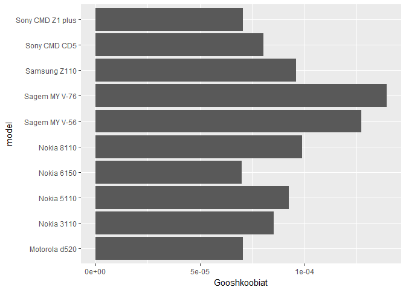

```r
Gooshkoobiat = ch

model = d

g = data.frame(model , Gooshkoobiat)


ggplot(g , aes(model , Gooshkoobiat)) + geom_col() + coord_flip()
```

۷. آیا تلفن همراهی وجود دارد که در آب غرق نشود؟ اگر جواب بله هست تمام گوشی های که این خاصیت را دارند بیابید. با کشیدن یک نمودار به این سوال پاسخ دهید.

```r
d = dim(mobile)

d = d[1]



den = NULL

for(i in 1:d){



  den = c(den , (((mobile[i , 9]) / (mobile[i , 7] * mobile[i , 6] * mobile[i , 8])) * 1000))



}

den1 <- den[!is.na(den)]

d = NULL

for(i in 1:length(den1)){

  if(den1[i] < 1){

  a = match(den1[i] , den)

  d = c(d , paste(mobile[a , 1] , mobile[a , 2]))

  print(paste(mobile[a , 1] , mobile[a , 2] , "     density = " , den1[i]))

  }
}
```

```
## [1] "alcatel 2040      density =  0.988538034730552"
## [1] "alcatel OT-308      density =  0.982961992136304"
## [1] "alcatel OT-292      density =  0.879957972156554"
## [1] "alcatel OT-228      density =  0.897251845775226"
## [1] "alcatel OT-665      density =  0.994646990740741"
## [1] "alcatel OT-361      density =  0.93564388483387"
## [1] "alcatel OT-223      density =  0.915086508356701"
## [1] "alcatel OT-217      density =  0.883009752985143"
## [1] "alcatel OT-213      density =  0.868302232326103"
## [1] "alcatel OT-209      density =  0.894614421184469"
## [1] "alcatel OT-117      density =  0.862776159090266"
## [1] "alcatel OT-113      density =  0.881458326755286"
## [1] "alcatel OT-113      density =  0.881458326755286"
## [1] "alcatel OT-109      density =  0.855146137896919"
## [1] "alcatel OT-109      density =  0.855146137896919"
```

[output cut: 999 more lines]

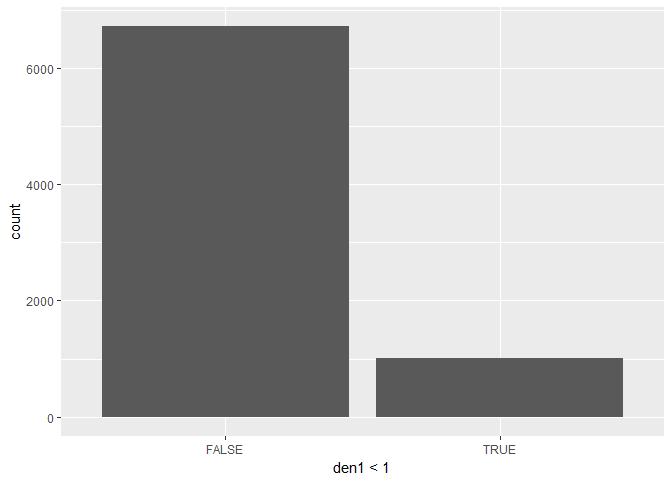

```r
g = data.frame(1 : 7726 , den1)


ggplot(g , aes(den1 < 1))  + geom_bar()
```

۸. نمودار پراکنش حجم ذخیره سازی باطری و وزن را رسم نمایید. میزان همبستگی بین این دو کمیت را محاسبه کنید.

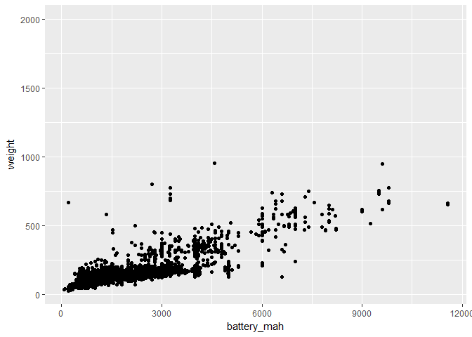

```r
ggplot(data = mobile  , aes(x = battery_mah , y = weight)) + geom_point()
```

```r
mobile1 = na.omit(mobile[,c("battery_mah" , "weight")])


cor(mobile1$battery_mah , mobile1$weight)
```

```
## [1] 0.8086273
```

۹. قیمت پرچمداران یک برند خاص مثلا سامسونگ را بیابید و نمودار قیمت زمان و نام مدل را رسم نمایید.

```r
#Q9 for Samsung


mobile1 = subset(mobile , mobile$company == "Samsung")




y = unique(mobile1$year)

y = sort(y)

p = NULL

n = NULL

for(i in y){

  mob = subset(mobile1 , mobile1$year == i)


  p = c(p , max(mob$price , na.rm = T))

  a = match(max(mob$price , na.rm = T) , mob$price)

  n = c(n , as.character(mob[a , 2]))

}
```

[output not shown]

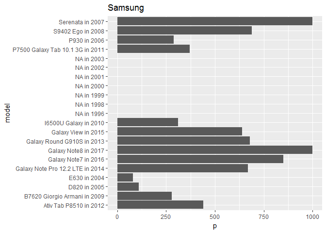

```r
model = NULL

for(i in 1:21){

  model = c(model , paste(n[i] ,"in" ,  y[i]))


}

g = data.frame(model , p)

ggplot(g , aes(model , p)) + geom_col() + coord_flip() + ggtitle("Samsung")
```

```r
#Q9 ffor LG


mobile1 = subset(mobile , mobile$company == "LG")


y = unique(mobile1$year)

y = sort(y)

p = NULL

n = NULL

for(i in y){

  mob = subset(mobile1 , mobile1$year == i)


  p = c(p , max(mob$price , na.rm = T))

  a = match(max(mob$price , na.rm = T) , mob$price)

  n = c(n , as.character(mob[a , 2]))


}
```

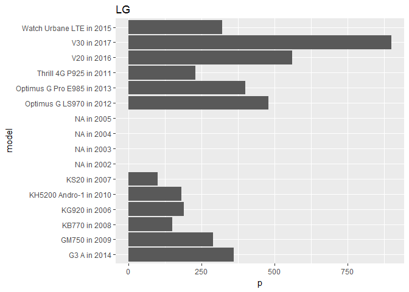

```r
model = NULL

for(i in 1:16){

  model = c(model , paste(n[i] ,"in" ,  y[i]))


}

g = data.frame(model , p)

ggplot(g , aes(model , p)) + geom_col() + coord_flip() + ggtitle("LG")
```

۱۰. سه نمودار جالب رسم کنید و توضیح دهید چرا از نظر شما جالب است؟

در این جا ابتدا نموداری کشیدیم که افزایش امکانات گوشی ها اعم از دور بین و ظرفیت باتری و کیفیت صفحه نمایش و… را بر حسب گذر زمان نشان می دهد. سپس نموداری کشیدیم که بر حسب گذر زمان افزایش اندازه صفحه نمایش را نشان می دهد که با توجه به نمودار علاقه مرئم به استفاده از گوشه هایی با صفحه نمایش تقریبا 5 اینچ می باشد. در انتها نموداری است که 20 کمپانی ای که قیمت دیوایس های عرضه شده توسط آن ها میانگین قیمتی بالا تری دارد به نمایش گذاشته شده است.

```r
#Q10



#INCREASE DEVICE OPTIONS

y = unique(mobile$year)



per = NULL

y = sort(y)

for(i in y){

  ad = NULL

  mob = subset(mobile , year == i)

  d = dim(mob)

  d = d[1]

  for(j in 1:d){

    a = ((mob[j , 12] * mob[j , 13] / mob[j , 11]) * mob[j , 18] * mob[j , 20] * mob[j , 28] * mob[j , 35] / mob[j , 3])

    ad = c(ad , a)

  }

  k = max(ad , na.rm = T)

  k = unique(k)

  per = c(per , k)
}
```

[output not shown]

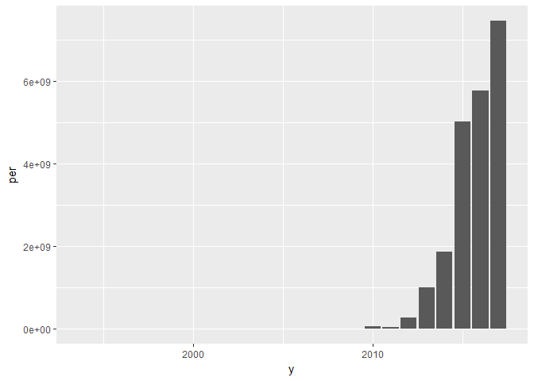

```r
g = data.frame(y , per)

ggplot(g , aes(y , per)) + geom_col()
```

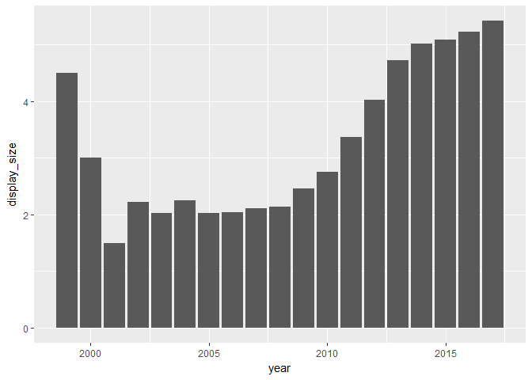

```r
#INCREASING DISPLAY SIZE

ggplot(mobile , aes(year , display_size)) + geom_bar(stat = "summary" , fun.y = "mean")
```

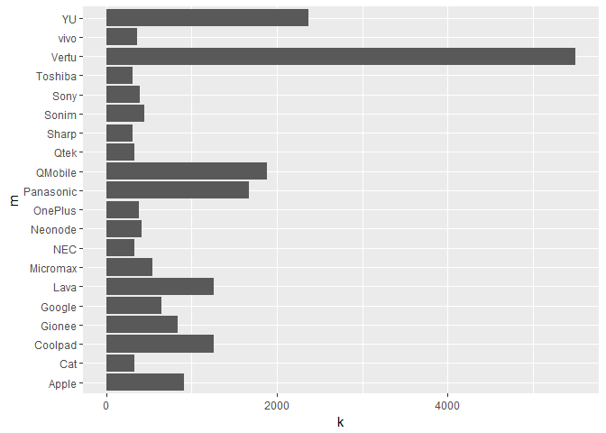

```r
#PRICE FROM COMPANY

y = unique(mobile$company)

y = as.character(y)

y = sort(y)

p = NULL

for(i in y){

  mob = subset(mobile , company == i)

  p = c(p , mean(mob$price , na.rm = T))


}

k = sort(p , decreasing = T)

k = k[1:20]

m = NULL

for(i in k){

  a = match(i , p)

  m = c(m , y[a])

}

g = data.frame(m , k)

ggplot(g , aes(m , k)) + geom_col() + coord_flip()
```